# Project Topic- Customer Segmentation using K Means Clustering

**Project for Module 2- Machine Learning**

Presenter : Tejinder Singh

### Table of Content

1. Data Description
2. Importing the dataset and packages
3. Exploratory Data Analysis
4. Finding Clusters with Elbow Method
5. Building K Means model

### 1. Data Description

**Retail data**  
This dataset represents the purchase behavior of customers at Spencers’ supermarket in Eastern part of India.

**Attributes**

- Customer_ID – id of customer
- AVG_Actual_price_12 – MRP (in INR)
- Purchase_Value – Total amount of purchase customer has made (in INR)
- No_of_Items – Number of items bought
- Total_Discount- Discount availed by each customer
- MONTH_SINCE_LAST_TRANSACTION – Last month of visit in supermarket

In this dataset, 702 rows of measurements of purchases made by various customers have been provided.

**Objective**

Cluster customers into different segments or groups based on the attributes given using clustering algorithms.

### 2. Importing the packages and dataset

```python
# Importing the packages

import pandas as pd
import numpy as np
from sklearn.cluster import KMeans
import matplotlib.pyplot as plt
import seaborn as sns
import pandas_profiling as pp
```

```python
%matplotlib inline
```

```python
# Importing the dataset

retail=pd.read_csv("Supermarket_Purchase.csv",index_col='Cust_id')
```

```python
retail.columns
```

```
Index(['AVG_Actual_price_12', 'Purchase_Value', 'No_of_Items',
       'Total_Discount', 'MONTH_SINCE_LAST_TRANSACTION'],
      dtype='object')
```

```python
retail.head()
```

| Cust_id | AVG_Actual_price_12 | Purchase_Value | No_of_Items | Total_Discount | MONTH_SINCE_LAST_TRANSACTION |
| --- | --- | --- | --- | --- | --- |
| 1 | 300.000000 | 1200.00 | 4 | 0.00 | 11 |
| 2 | 2563.282500 | 41012.52 | 16 | 78737.48 | 2 |
| 4 | 3510.000000 | 7020.00 | 2 | 780.00 | 4 |
| 8 | 4530.000000 | 13590.00 | 3 | 1510.00 | 1 |
| 9 | 2428.076923 | 33455.00 | 15 | 17445.00 | 6 |

```python
retail.describe()
```

|  | AVG_Actual_price_12 | Purchase_Value | No_of_Items | Total_Discount | MONTH_SINCE_LAST_TRANSACTION |
| --- | --- | --- | --- | --- | --- |
| count | 702.000000 | 702.000000 | 702.000000 | 702.000000 | 702.000000 |
| mean | 2642.877917 | 19820.633305 | 10.720798 | 20806.339088 | 5.029915 |
| std | 1879.138285 | 34639.752609 | 20.038311 | 58427.798572 | 3.562840 |
| min | 22.500000 | 45.000000 | 1.000000 | -3962.480000 | 1.000000 |
| 25% | 1238.750000 | 4200.000000 | 2.000000 | 0.000000 | 2.000000 |
| 50% | 2100.000000 | 8660.000000 | 4.000000 | 2599.250000 | 4.000000 |
| 75% | 3700.000000 | 21197.000000 | 10.000000 | 17433.750000 | 8.000000 |
| max | 10000.000000 | 302721.740000 | 172.000000 | 734349.820000 | 12.000000 |

```python
retail.info()
```

```
<class 'pandas.core.frame.DataFrame'>
Int64Index: 702 entries, 1 to 1006
Data columns (total 5 columns):
AVG_Actual_price_12             702 non-null float64
Purchase_Value                  702 non-null float64
No_of_Items                     702 non-null int64
Total_Discount                  702 non-null float64
MONTH_SINCE_LAST_TRANSACTION    702 non-null int64
dtypes: float64(3), int64(2)
memory usage: 32.9 KB
```

```python
# Checking the null values in the dataset

retail.isnull().sum()
```

```
AVG_Actual_price_12             0
Purchase_Value                  0
No_of_Items                     0
Total_Discount                  0
MONTH_SINCE_LAST_TRANSACTION    0
dtype: int64
```

### 3. Exploratory Data Analysis

# **Exploraty Data Analysis**

#### Profile Report

Overview

Dataset info

| Number of variables | 6 |
| --- | --- |
| Number of observations | 702 |
| Total Missing (%) | 0.0% |
| Total size in memory | 33.0 KiB |
| Average record size in memory | 48.1 B |

Variables types

| Numeric | 6 |
| --- | --- |
| Categorical | 0 |
| Boolean | 0 |
| Date | 0 |
| Text (Unique) | 0 |
| Rejected | 0 |
| Unsupported | 0 |

Warnings

- `Total_Discount` has 178 / 25.4% zeros Zeros

Variables

AVG_Actual_price_12  
Numeric

| Distinct count | 514 |
| --- | --- |
| Unique (%) | 73.2% |
| Missing (%) | 0.0% |
| Missing (n) | 0 |
| Infinite (%) | 0.0% |
| Infinite (n) | 0 |

| Mean | 2642.9 |
| --- | --- |
| Minimum | 22.5 |
| Maximum | 10000 |
| Zeros (%) | 0.0% |

Toggle details

**Statistics**

Quantile statistics

| Minimum | 22.5 |
| --- | --- |
| 5-th percentile | 440.26 |
| Q1 | 1238.7 |
| Median | 2100 |
| Q3 | 3700 |
| 95-th percentile | 6439.8 |
| Maximum | 10000 |
| Range | 9977.5 |
| Interquartile range | 2461.3 |

Descriptive statistics

| Standard deviation | 1879.1 |
| --- | --- |
| Coef of variation | 0.71102 |
| Kurtosis | 1.1956 |
| Mean | 2642.9 |
| MAD | 1486.9 |
| Skewness | 1.1864 |
| Sum | 1855300 |
| Variance | 3531200 |
| Memory size | 5.6 KiB |

**Histogram**

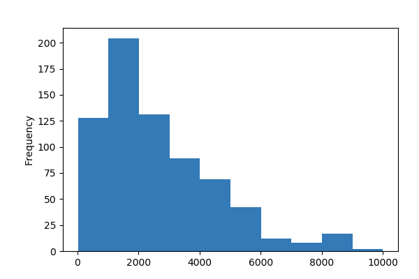

**Common Values**

| Value | Count | Frequency (%) |  |
| --- | --- | --- | --- |
| 2100.0 | 26 | 3.7% |  |
| 8300.0 | 10 | 1.4% |  |
| 4150.0 | 9 | 1.3% |  |
| 5100.0 | 8 | 1.1% |  |
| 300.0 | 7 | 1.0% |  |
| 5200.0 | 7 | 1.0% |  |
| 5400.0 | 6 | 0.9% |  |
| 1050.0 | 6 | 0.9% |  |
| 650.0 | 6 | 0.9% |  |
| 6000.0 | 6 | 0.9% |  |
| Other values (504) | 611 | 87.0% |  |

**Extreme Values**

Minimum 5 values

| Value | Count | Frequency (%) |  |
| --- | --- | --- | --- |
| 22.5 | 1 | 0.1% |  |
| 50.0 | 1 | 0.1% |  |
| 125.0 | 1 | 0.1% |  |
| 150.0 | 1 | 0.1% |  |
| 202.5 | 1 | 0.1% |  |

Maximum 5 values

| Value | Count | Frequency (%) |  |
| --- | --- | --- | --- |
| 8500.0 | 2 | 0.3% |  |
| 8536.32 | 1 | 0.1% |  |
| 8625.0 | 1 | 0.1% |  |
| 9466.666667 | 1 | 0.1% |  |
| 10000.0 | 1 | 0.1% |  |

Cust_id  
Numeric

| Distinct count | 702 |
| --- | --- |
| Unique (%) | 100.0% |
| Missing (%) | 0.0% |
| Missing (n) | 0 |
| Infinite (%) | 0.0% |
| Infinite (n) | 0 |

| Mean | 501.41 |
| --- | --- |
| Minimum | 1 |
| Maximum | 1006 |
| Zeros (%) | 0.0% |

Toggle details

**Statistics**

Quantile statistics

| Minimum | 1 |
| --- | --- |
| 5-th percentile | 51.15 |
| Q1 | 245.75 |
| Median | 486.5 |
| Q3 | 763.75 |
| 95-th percentile | 961.95 |
| Maximum | 1006 |
| Range | 1005 |
| Interquartile range | 518 |

Descriptive statistics

| Standard deviation | 295.76 |
| --- | --- |
| Coef of variation | 0.58984 |
| Kurtosis | -1.2292 |
| Mean | 501.41 |
| MAD | 256.59 |
| Skewness | 0.057814 |
| Sum | 351993 |
| Variance | 87472 |
| Memory size | 5.6 KiB |

**Histogram**

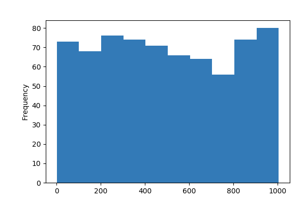

**Common Values**

| Value | Count | Frequency (%) |  |
| --- | --- | --- | --- |
| 1006 | 1 | 0.1% |  |
| 322 | 1 | 0.1% |  |
| 331 | 1 | 0.1% |  |
| 330 | 1 | 0.1% |  |
| 329 | 1 | 0.1% |  |
| 327 | 1 | 0.1% |  |
| 326 | 1 | 0.1% |  |
| 325 | 1 | 0.1% |  |
| 324 | 1 | 0.1% |  |
| 323 | 1 | 0.1% |  |
| Other values (692) | 692 | 98.6% |  |

**Extreme Values**

Minimum 5 values

| Value | Count | Frequency (%) |  |
| --- | --- | --- | --- |
| 1 | 1 | 0.1% |  |
| 2 | 1 | 0.1% |  |
| 4 | 1 | 0.1% |  |
| 8 | 1 | 0.1% |  |
| 9 | 1 | 0.1% |  |

Maximum 5 values

| Value | Count | Frequency (%) |  |
| --- | --- | --- | --- |
| 1002 | 1 | 0.1% |  |
| 1003 | 1 | 0.1% |  |
| 1004 | 1 | 0.1% |  |
| 1005 | 1 | 0.1% |  |
| 1006 | 1 | 0.1% |  |

MONTH_SINCE_LAST_TRANSACTION  
Numeric

| Distinct count | 12 |
| --- | --- |
| Unique (%) | 1.7% |
| Missing (%) | 0.0% |
| Missing (n) | 0 |
| Infinite (%) | 0.0% |
| Infinite (n) | 0 |

| Mean | 5.0299 |
| --- | --- |
| Minimum | 1 |
| Maximum | 12 |
| Zeros (%) | 0.0% |

Toggle details

**Statistics**

Quantile statistics

| Minimum | 1 |
| --- | --- |
| 5-th percentile | 1 |
| Q1 | 2 |
| Median | 4 |
| Q3 | 8 |
| 95-th percentile | 12 |
| Maximum | 12 |
| Range | 11 |
| Interquartile range | 6 |

Descriptive statistics

| Standard deviation | 3.5628 |
| --- | --- |
| Coef of variation | 0.70833 |
| Kurtosis | -0.96969 |
| Mean | 5.0299 |
| MAD | 3.0391 |
| Skewness | 0.54004 |
| Sum | 3531 |
| Variance | 12.694 |
| Memory size | 5.6 KiB |

**Histogram**

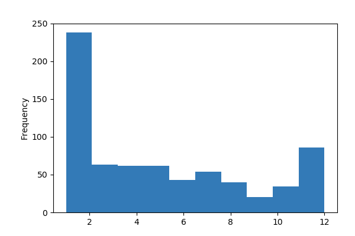

**Common Values**

| Value | Count | Frequency (%) |  |
| --- | --- | --- | --- |
| 1 | 152 | 21.7% |  |
| 2 | 86 | 12.3% |  |
| 3 | 63 | 9.0% |  |
| 5 | 62 | 8.8% |  |
| 4 | 62 | 8.8% |  |
| 7 | 54 | 7.7% |  |
| 11 | 48 | 6.8% |  |
| 6 | 43 | 6.1% |  |
| 8 | 40 | 5.7% |  |
| 12 | 38 | 5.4% |  |
| Other values (2) | 54 | 7.7% |  |

**Extreme Values**

Minimum 5 values

| Value | Count | Frequency (%) |  |
| --- | --- | --- | --- |
| 1 | 152 | 21.7% |  |
| 2 | 86 | 12.3% |  |
| 3 | 63 | 9.0% |  |
| 4 | 62 | 8.8% |  |
| 5 | 62 | 8.8% |  |

Maximum 5 values

| Value | Count | Frequency (%) |  |
| --- | --- | --- | --- |
| 8 | 40 | 5.7% |  |
| 9 | 20 | 2.8% |  |
| 10 | 34 | 4.8% |  |
| 11 | 48 | 6.8% |  |
| 12 | 38 | 5.4% |  |

No_of_Items  
Numeric

| Distinct count | 67 |
| --- | --- |
| Unique (%) | 9.5% |
| Missing (%) | 0.0% |
| Missing (n) | 0 |
| Infinite (%) | 0.0% |
| Infinite (n) | 0 |

| Mean | 10.721 |
| --- | --- |
| Minimum | 1 |
| Maximum | 172 |
| Zeros (%) | 0.0% |

Toggle details

**Statistics**

Quantile statistics

| Minimum | 1 |
| --- | --- |
| 5-th percentile | 1 |
| Q1 | 2 |
| Median | 4 |
| Q3 | 10 |
| 95-th percentile | 42 |
| Maximum | 172 |
| Range | 171 |
| Interquartile range | 8 |

Descriptive statistics

| Standard deviation | 20.038 |
| --- | --- |
| Coef of variation | 1.8691 |
| Kurtosis | 26.482 |
| Mean | 10.721 |
| MAD | 10.903 |
| Skewness | 4.6223 |
| Sum | 7526 |
| Variance | 401.53 |
| Memory size | 5.6 KiB |

**Histogram**

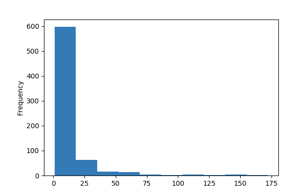

**Common Values**

| Value | Count | Frequency (%) |  |
| --- | --- | --- | --- |
| 1 | 133 | 18.9% |  |
| 2 | 120 | 17.1% |  |
| 4 | 77 | 11.0% |  |
| 3 | 52 | 7.4% |  |
| 5 | 41 | 5.8% |  |
| 6 | 40 | 5.7% |  |
| 10 | 25 | 3.6% |  |
| 8 | 24 | 3.4% |  |
| 12 | 13 | 1.9% |  |
| 7 | 12 | 1.7% |  |
| Other values (57) | 165 | 23.5% |  |

**Extreme Values**

Minimum 5 values

| Value | Count | Frequency (%) |  |
| --- | --- | --- | --- |
| 1 | 133 | 18.9% |  |
| 2 | 120 | 17.1% |  |
| 3 | 52 | 7.4% |  |
| 4 | 77 | 11.0% |  |
| 5 | 41 | 5.8% |  |

Maximum 5 values

| Value | Count | Frequency (%) |  |
| --- | --- | --- | --- |
| 146 | 1 | 0.1% |  |
| 149 | 1 | 0.1% |  |
| 154 | 1 | 0.1% |  |
| 168 | 1 | 0.1% |  |
| 172 | 1 | 0.1% |  |

Purchase_Value  
Numeric

| Distinct count | 511 |
| --- | --- |
| Unique (%) | 72.8% |
| Missing (%) | 0.0% |
| Missing (n) | 0 |
| Infinite (%) | 0.0% |
| Infinite (n) | 0 |

| Mean | 19821 |
| --- | --- |
| Minimum | 45 |
| Maximum | 302720 |
| Zeros (%) | 0.0% |

Toggle details

**Statistics**

Quantile statistics

| Minimum | 45 |
| --- | --- |
| 5-th percentile | 1004 |
| Q1 | 4200 |
| Median | 8660 |
| Q3 | 21197 |
| 95-th percentile | 68193 |
| Maximum | 302720 |
| Range | 302680 |
| Interquartile range | 16997 |

Descriptive statistics

| Standard deviation | 34640 |
| --- | --- |
| Coef of variation | 1.7477 |
| Kurtosis | 27.695 |
| Mean | 19821 |
| MAD | 18603 |
| Skewness | 4.7115 |
| Sum | 13914000 |
| Variance | 1199900000 |
| Memory size | 5.6 KiB |

**Histogram**

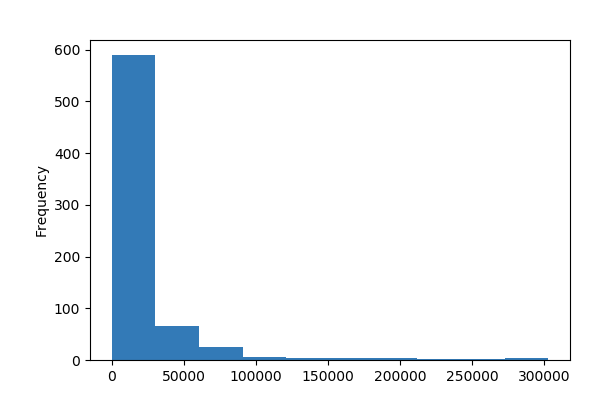

**Common Values**

| Value | Count | Frequency (%) |  |
| --- | --- | --- | --- |
| 2100.0 | 21 | 3.0% |  |
| 8300.0 | 13 | 1.9% |  |
| 6000.0 | 10 | 1.4% |  |
| 4200.0 | 10 | 1.4% |  |
| 5100.0 | 8 | 1.1% |  |
| 1890.0 | 7 | 1.0% |  |
| 3500.0 | 7 | 1.0% |  |
| 650.0 | 6 | 0.9% |  |
| 6750.0 | 6 | 0.9% |  |
| 5400.0 | 6 | 0.9% |  |
| Other values (501) | 608 | 86.6% |  |

**Extreme Values**

Minimum 5 values

| Value | Count | Frequency (%) |  |
| --- | --- | --- | --- |
| 45.0 | 1 | 0.1% |  |
| 200.0 | 1 | 0.1% |  |
| 300.0 | 2 | 0.3% |  |
| 337.5 | 1 | 0.1% |  |
| 450.0 | 1 | 0.1% |  |

Maximum 5 values

| Value | Count | Frequency (%) |  |
| --- | --- | --- | --- |
| 234203.0 | 1 | 0.1% |  |
| 256450.0 | 1 | 0.1% |  |
| 286244.5 | 1 | 0.1% |  |
| 298429.24 | 1 | 0.1% |  |
| 302721.74 | 1 | 0.1% |  |

Total_Discount  
Numeric

| Distinct count | 454 |
| --- | --- |
| Unique (%) | 64.7% |
| Missing (%) | 0.0% |
| Missing (n) | 0 |
| Infinite (%) | 0.0% |
| Infinite (n) | 0 |

| Mean | 20806 |
| --- | --- |
| Minimum | -3962.5 |
| Maximum | 734350 |
| Zeros (%) | 25.4% |

Toggle details

**Statistics**

Quantile statistics

| Minimum | -3962.5 |
| --- | --- |
| 5-th percentile | 0 |
| Q1 | 0 |
| Median | 2599.2 |
| Q3 | 17434 |
| 95-th percentile | 81817 |
| Maximum | 734350 |
| Range | 738310 |
| Interquartile range | 17434 |

Descriptive statistics

| Standard deviation | 58428 |
| --- | --- |
| Coef of variation | 2.8082 |
| Kurtosis | 57.366 |
| Mean | 20806 |
| MAD | 26742 |
| Skewness | 6.6559 |
| Sum | 14606000 |
| Variance | 3413800000 |
| Memory size | 5.6 KiB |

**Histogram**

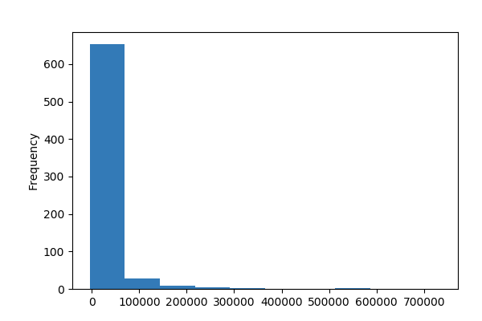

**Common Values**

| Value | Count | Frequency (%) |  |
| --- | --- | --- | --- |
| 0.0 | 178 | 25.4% |  |
| 8300.0 | 6 | 0.9% |  |
| 600.0 | 5 | 0.7% |  |
| 6300.0 | 4 | 0.6% |  |
| 2100.0 | 4 | 0.6% |  |
| 510.0 | 4 | 0.6% |  |
| 1050.0 | 3 | 0.4% |  |
| 2310.0 | 3 | 0.4% |  |
| 7500.0 | 3 | 0.4% |  |
| 1500.0 | 3 | 0.4% |  |
| Other values (444) | 489 | 69.7% |  |

**Extreme Values**

Minimum 5 values

| Value | Count | Frequency (%) |  |
| --- | --- | --- | --- |
| -3962.48 | 1 | 0.1% |  |
| -2495.64 | 1 | 0.1% |  |
| -1411.8 | 1 | 0.1% |  |
| -1172.16 | 1 | 0.1% |  |
| -962.37 | 1 | 0.1% |  |

Maximum 5 values

| Value | Count | Frequency (%) |  |
| --- | --- | --- | --- |
| 406350.0 | 1 | 0.1% |  |
| 441726.76 | 1 | 0.1% |  |
| 524174.0 | 1 | 0.1% |  |
| 536197.0 | 1 | 0.1% |  |
| 734349.82 | 1 | 0.1% |  |

Correlations

Sample

| Cust_id | AVG_Actual_price_12 | Purchase_Value | No_of_Items | Total_Discount | MONTH_SINCE_LAST_TRANSACTION |
| --- | --- | --- | --- | --- | --- |
| 1 | 300.000000 | 1200.00 | 4 | 0.00 | 11 |
| 2 | 2563.282500 | 41012.52 | 16 | 78737.48 | 2 |
| 4 | 3510.000000 | 7020.00 | 2 | 780.00 | 4 |
| 8 | 4530.000000 | 13590.00 | 3 | 1510.00 | 1 |
| 9 | 2428.076923 | 33455.00 | 15 | 17445.00 | 6 |

```python
pp.ProfileReport(retail)
```

#### Box Plot

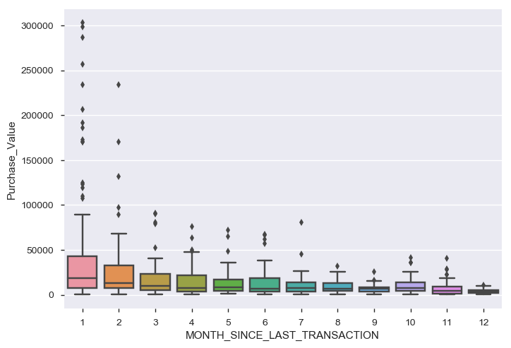

```python
# This shows comparision of items purchased by different retail customers

sns.boxplot(x = 'MONTH_SINCE_LAST_TRANSACTION', y='Purchase_Value', data = retail)
```

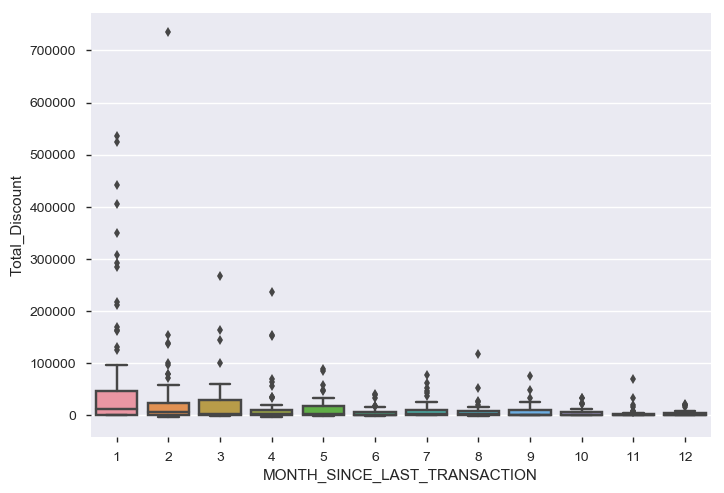

```python
# This shows variation of MONTH_SINCE_LAST_TRANSACTION with Total_Discount

sns.boxplot(x = 'MONTH_SINCE_LAST_TRANSACTION', y='Total_Discount', data = retail)
```

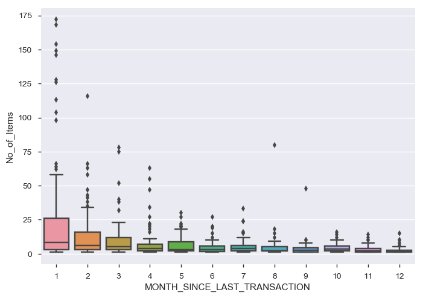

```python
# This shows variation of MONTH_SINCE_LAST_TRANSACTION vis-a-vis No_of_items

sns.boxplot(x = 'MONTH_SINCE_LAST_TRANSACTION', y='No_of_Items', data = retail)
```

#### Correlation plot

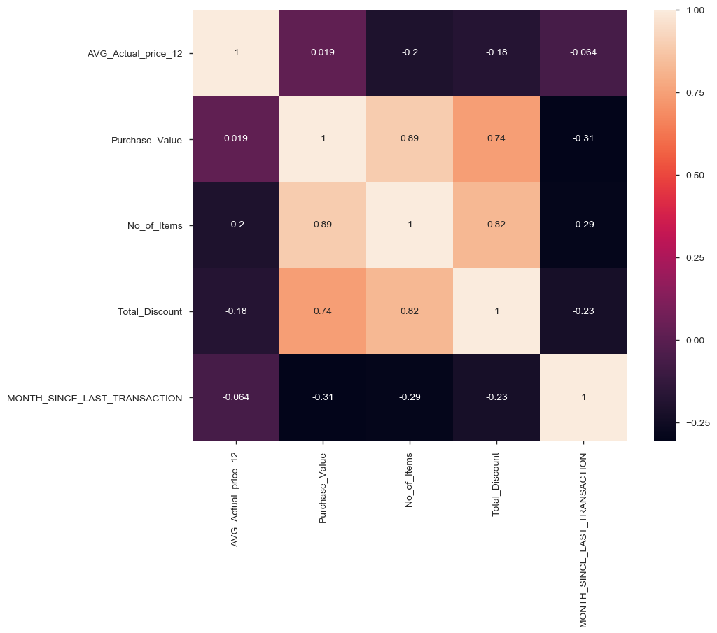

```python
figsize=[10,8]
plt.figure(figsize=figsize)
sns.heatmap(retail.corr(),annot=True)
plt.show()
```

**Strong positive correlation between**  
No. of Items -- Purchase Value  
Total Discount is more strongly correlated with No. of Items (0.82) than Purchase_Value (0.74) indicating that discounts coupons are offered per unit item instead of total purchase value

#### Histogram

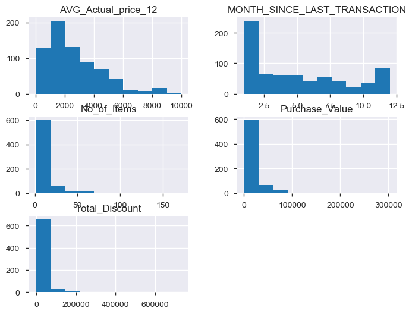

```python
## Shows distribution of the variables
retail.hist(figsize=(8,6))
plt.show()
```

#### Pairplot

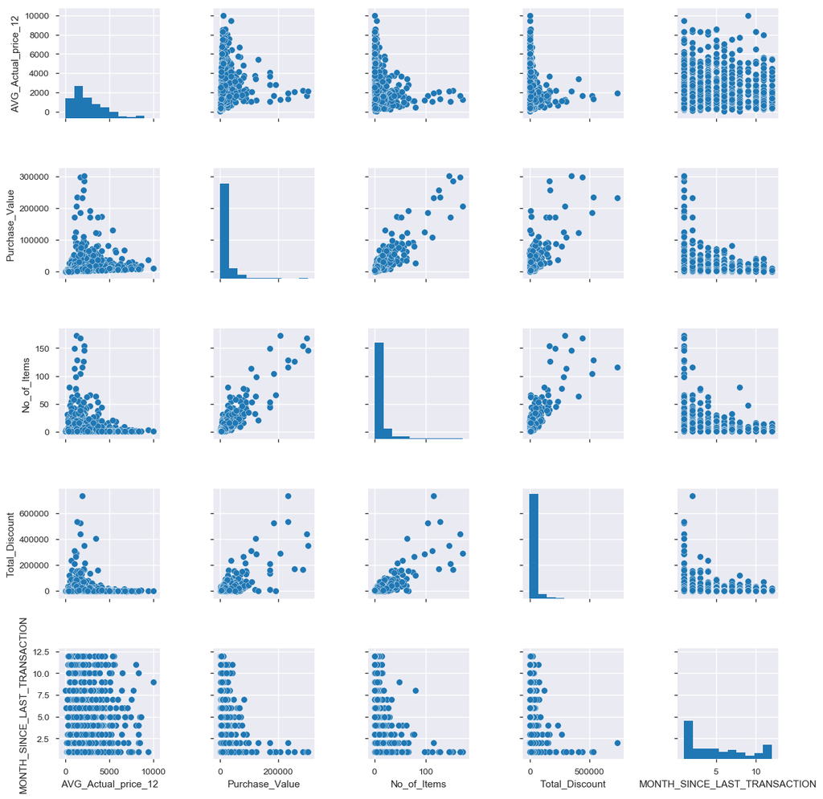

```python
sns.pairplot(retail)
```

# Demystifying Total_Discount

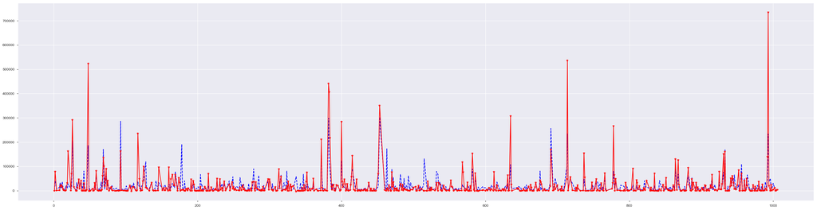

```python
# IF you closely observe , you will find value of 'Total_Discount' is higher than 'Purchase_Value' which cannot be the case.
# Also, sometime, 'Total_Discount' is having negative values. Lets analyse these values and try to demystify it.

cust_id = retail.index
purchase_value = retail['Purchase_Value']

total_discount = retail['Total_Discount'];

plt.figure(figsize=(40,10))
plt.plot(cust_id, purchase_value, 'b--', cust_id, total_discount, 'r*-')
```

```python
retail.tail(20)
```

| Cust_id | AVG_Actual_price_12 | Purchase_Value | No_of_Items | Total_Discount | MONTH_SINCE_LAST_TRANSACTION |
| --- | --- | --- | --- | --- | --- |
| 982 | 1350.000000 | 2700.00 | 2 | 300.00 | 4 |
| 983 | 4563.600000 | 4563.60 | 1 | -95.60 | 11 |
| 984 | 3488.000000 | 17440.00 | 5 | 860.00 | 7 |
| 985 | 1867.500000 | 7470.00 | 4 | 25730.00 | 1 |
| 986 | 650.000000 | 650.00 | 1 | 0.00 | 11 |
| 988 | 4590.000000 | 4590.00 | 1 | 510.00 | 3 |
| 989 | 4134.375000 | 36435.00 | 10 | 8915.00 | 3 |
| 991 | 5001.165000 | 10002.33 | 2 | 1397.67 | 2 |
| 992 | 1683.000000 | 54270.00 | 38 | 139530.00 | 2 |
| 993 | 1891.162000 | 233556.18 | 116 | 734349.82 | 2 |
| 994 | 3655.555556 | 36470.00 | 11 | 20225.00 | 1 |
| 996 | 3163.142857 | 50284.00 | 16 | 166.00 | 4 |
| 997 | 2746.666667 | 16480.00 | 6 | 24720.00 | 2 |
| 998 | 1347.750000 | 2695.50 | 2 | 299.50 | 1 |
| 1000 | 1575.000000 | 30780.00 | 17 | 4220.00 | 2 |
| 1002 | 2210.000000 | 8840.00 | 4 | 11960.00 | 1 |
| 1003 | 2500.000000 | 2500.00 | 1 | 0.00 | 5 |
| 1004 | 347.045000 | 694.09 | 2 | 605.91 | 12 |
| 1005 | 3750.000000 | 3750.00 | 1 | 3750.00 | 12 |
| 1006 | 4150.000000 | 4150.00 | 1 | 4150.00 | 12 |

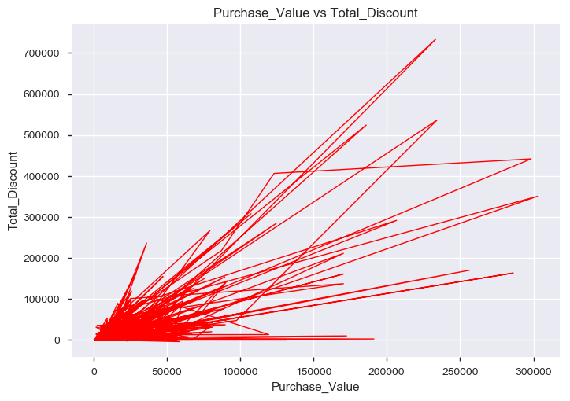

```python
#scatter plots
plt.plot(retail.Purchase_Value,retail.Total_Discount,'b',color ='red', linewidth = 1.0)
#plt.plot(retail.Purchase_Value,retail.Total_Discount)
plt.xlabel ('Purchase_Value')
plt.ylabel ('Total_Discount')
plt.title ('Purchase_Value vs Total_Discount')
plt.show()
```

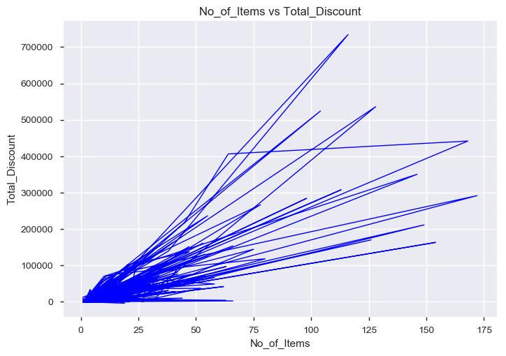

```python
#scatter plots
plt.plot(retail.No_of_Items,retail.Total_Discount,'b',color ='blue', linewidth = 1.0)
#plt.plot(retail.No_of_Items,retail.Total_Discount)
plt.xlabel ('No_of_Items')
plt.ylabel ('Total_Discount')
plt.title ('No_of_Items vs Total_Discount')
plt.show()
```

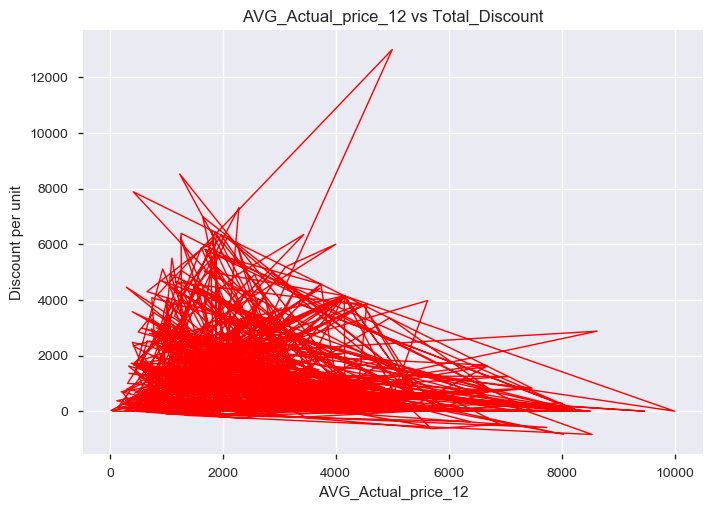

```python
#scatter plots
plt.plot(retail.AVG_Actual_price_12,retail.Total_Discount/retail.No_of_Items,color ='red', linewidth = 1.0)
#plt.plot(retail.AVG_Actual_price_12,retail.Total_Discount/retail.No_of_Items)
plt.xlabel ('AVG_Actual_price_12')
plt.ylabel ('Discount per unit')
plt.title ('AVG_Actual_price_12 vs Total_Discount')
plt.show()
```

```python
# Lets quickly try to establish an equation for Total_Discount as a function of AVG_Actual_price_12,Purchase_Value & No_of_Items
# using Linear Regression
from sklearn.model_selection import train_test_split
from sklearn import metrics
from sklearn.linear_model import LinearRegression
```

```python
# Print multiple statements in same line
from IPython.core.interactiveshell import InteractiveShell
InteractiveShell.ast_node_interactivity = "all"
```

```python
retail.columns
```

```
Index(['AVG_Actual_price_12', 'Purchase_Value', 'No_of_Items',
       'Total_Discount', 'MONTH_SINCE_LAST_TRANSACTION'],
      dtype='object')
```

```python
#x = retail.drop(['Total_Discount','MONTH_SINCE_LAST_TRANSACTION'], axis = 1, inplace=False)
x = retail.drop(['Total_Discount'], axis = 1, inplace=False)
y = retail['Total_Discount']
x.shape
y.shape
```

```
(702, 4)
```

```
(702,)
```

```python
# Split in Train and Test data
x_train, x_test, y_train, y_test = train_test_split(x, y, test_size=0.2, random_state=42)
x_train.shape
y_train.shape
x_test.shape
y_test.shape
```

```
(561, 4)
```

```
(561,)
```

```
(141, 4)
```

```
(141,)
```

```python
from sklearn.linear_model import LinearRegression
lm = LinearRegression()
lm.fit(x_train, y_train)
```

```
LinearRegression(copy_X=True, fit_intercept=True, n_jobs=1, normalize=False)
```

```python
predicted = lm.predict(x_test)
predicted.shape
```

```
(141,)
```

```python
metrics.mean_squared_error(y_test, predicted)
metrics.mean_absolute_error(y_test,predicted)
metrics.median_absolute_error(y_test, predicted)
```

```
1341286677.67272
```

```
14205.124491970244
```

```
6283.600618958124
```

```python
lm.coef_
lm.intercept_
x.columns
```

```
array([-1.25896702e+00,  1.75441244e-01,  2.04138163e+03,  1.49740812e+02])
```

```
-2021.0323965047646
```

```
Index(['AVG_Actual_price_12', 'Purchase_Value', 'No_of_Items',
       'MONTH_SINCE_LAST_TRANSACTION'],
      dtype='object')
```

**With this analysis, it is clear now that...**

- Total_Discount is highly dependent on No_of_items and MONTH_SINCE_LAST_TRANSACTION
- while it is nominally dependent on Purchase_Value
- Also, it is slightly negatively dependent on Avg_Price

```python
# Lets consider Negative Values of Total_Discounts as 'Lapsed Discount points', and try to find some pattern in it.
# Add a new column to separate out Negative discount values

retail['discount_lapse'] = np.where(retail['Total_Discount']<0, 'Yes','No')
retail1=pd.pivot_table(retail, index=['MONTH_SINCE_LAST_TRANSACTION'], values=['Total_Discount'],columns=['discount_lapse'],aggfunc=np.sum).fillna(0)
retail1
```

| discount_lapse MONTH_SINCE_LAST_TRANSACTION | Total_Discount No | Total_Discount Yes |
| --- | --- | --- |
| 1 | 7016359.48 | 0.00 |
| 2 | 2501039.45 | -3962.48 |
| 3 | 1351708.77 | -1358.01 |
| 4 | 1023710.42 | -3528.82 |
| 5 | 760359.12 | -3138.76 |
| 6 | 254747.35 | -528.62 |
| 7 | 572452.29 | 0.00 |
| 8 | 367116.12 | -1172.16 |
| 9 | 229887.30 | 0.00 |
| 10 | 199033.76 | 0.00 |
| 11 | 200464.14 | -327.87 |
| 12 | 143188.56 | 0.00 |

```python
retail.drop('discount_lapse',axis=1, inplace=True)
```

**After analysing Total_Discount, Now lets go with clustering exercise**

```python
retail.columns
```

```
Index(['AVG_Actual_price_12', 'Purchase_Value', 'No_of_Items',
       'Total_Discount', 'MONTH_SINCE_LAST_TRANSACTION'],
      dtype='object')
```

### 4. Finding Clusters with Elbow Method

```python
# Sum Squared Within -> ssw[]
ssw=[]
cluster_range=range(1,10)
for i in cluster_range:
    model=KMeans(n_clusters=i,init="k-means++",n_init=10, max_iter=300, random_state=0)
    model.fit(retail)
    ssw.append(model.inertia_)
```

```
KMeans(algorithm='auto', copy_x=True, init='k-means++', max_iter=300,
    n_clusters=1, n_init=10, n_jobs=1, precompute_distances='auto',
    random_state=0, tol=0.0001, verbose=0)
```

```
KMeans(algorithm='auto', copy_x=True, init='k-means++', max_iter=300,
    n_clusters=2, n_init=10, n_jobs=1, precompute_distances='auto',
    random_state=0, tol=0.0001, verbose=0)
```

```
KMeans(algorithm='auto', copy_x=True, init='k-means++', max_iter=300,
    n_clusters=3, n_init=10, n_jobs=1, precompute_distances='auto',
    random_state=0, tol=0.0001, verbose=0)
```

```
KMeans(algorithm='auto', copy_x=True, init='k-means++', max_iter=300,
    n_clusters=4, n_init=10, n_jobs=1, precompute_distances='auto',
    random_state=0, tol=0.0001, verbose=0)
```

```
KMeans(algorithm='auto', copy_x=True, init='k-means++', max_iter=300,
    n_clusters=5, n_init=10, n_jobs=1, precompute_distances='auto',
    random_state=0, tol=0.0001, verbose=0)
```

```
KMeans(algorithm='auto', copy_x=True, init='k-means++', max_iter=300,
    n_clusters=6, n_init=10, n_jobs=1, precompute_distances='auto',
    random_state=0, tol=0.0001, verbose=0)
```

```
KMeans(algorithm='auto', copy_x=True, init='k-means++', max_iter=300,
    n_clusters=7, n_init=10, n_jobs=1, precompute_distances='auto',
    random_state=0, tol=0.0001, verbose=0)
```

```
KMeans(algorithm='auto', copy_x=True, init='k-means++', max_iter=300,
    n_clusters=8, n_init=10, n_jobs=1, precompute_distances='auto',
    random_state=0, tol=0.0001, verbose=0)
```

```
KMeans(algorithm='auto', copy_x=True, init='k-means++', max_iter=300,
    n_clusters=9, n_init=10, n_jobs=1, precompute_distances='auto',
    random_state=0, tol=0.0001, verbose=0)
```

```python
ssw_df=pd.DataFrame({"no. of clusters":cluster_range,"SSW":ssw})
print(ssw_df)
```

```
            SSW  no. of clusters
0  3.236693e+12                1
1  1.224767e+12                2
2  8.049189e+11                3
3  5.329084e+11                4
4  4.506194e+11                5
5  3.731772e+11                6
6  3.145581e+11                7
7  2.623527e+11                8
8  2.281560e+11                9
```

```
Text(0.5,0,'Number of clusters')
```

```
Text(0,0.5,'sum squared within')
```

```
Text(0.5,1,'Elbow method to find optimal number of clusters')
```

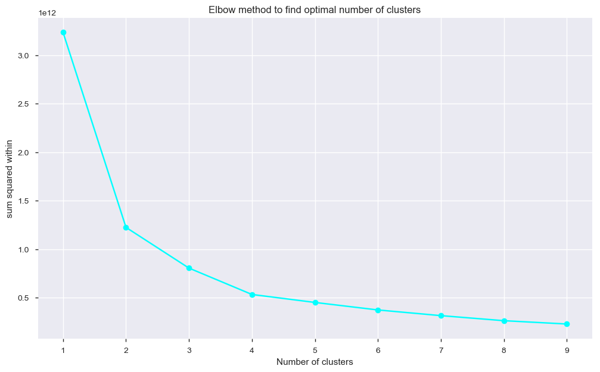

```python
plt.figure(figsize=(12,7))
plt.plot(cluster_range, ssw, marker = "o",color="cyan")
plt.xlabel("Number of clusters")
plt.ylabel("sum squared within")
plt.title("Elbow method to find optimal number of clusters")
plt.show()
```

**Though Elbow is spotted at No. of clusters=2, while there is no significant change after 4. So for our purpose we will consider optimal No. of Clusters as 3 in order to get more insights**

### 5. Building K Means model

```python
# We'll continue our analysis with n_clusters=3
kmeans=KMeans(n_clusters=3, init="k-means++", n_init=10, random_state = 42)
# Fit the model
k_model=kmeans.fit(retail)
```

```python
## It returns the cluster vectors i.e. showing observations belonging which clusters
clusters=k_model.labels_
clusters
```

```
array([0, 0, 0, 0, 0, 0, 0, 0, 0, 0, 0, 0, 0, 1, 0, 0, 1, 0, 0, 0, 0, 0,
       0, 0, 0, 0, 0, 0, 0, 0, 0, 0, 2, 0, 0, 0, 0, 0, 0, 0, 0, 0, 0, 0,
       0, 0, 0, 0, 0, 0, 1, 0, 0, 0, 0, 0, 0, 0, 0, 0, 0, 0, 0, 0, 0, 0,
       0, 1, 0, 0, 0, 0, 0, 0, 0, 0, 0, 0, 0, 0, 0, 0, 0, 1, 0, 0, 0, 0,
       0, 0, 0, 0, 0, 0, 0, 0, 0, 0, 0, 0, 0, 0, 0, 0, 0, 0, 0, 0, 0, 0,
       0, 0, 0, 0, 0, 0, 0, 0, 0, 0, 0, 0, 0, 0, 0, 0, 0, 0, 0, 0, 0, 0,
       0, 0, 0, 0, 0, 0, 0, 0, 0, 0, 0, 0, 0, 0, 0, 0, 0, 0, 0, 0, 0, 0,
       0, 0, 0, 0, 0, 0, 0, 0, 0, 0, 0, 0, 0, 0, 0, 0, 0, 0, 0, 0, 0, 0,
       0, 0, 0, 0, 0, 0, 0, 0, 0, 0, 0, 0, 0, 0, 0, 0, 0, 0, 0, 0, 0, 0,
       0, 0, 0, 0, 0, 0, 0, 0, 0, 0, 0, 0, 0, 0, 0, 0, 0, 0, 0, 0, 0, 0,
       0, 0, 0, 0, 0, 0, 0, 0, 0, 0, 0, 0, 0, 0, 0, 0, 0, 0, 0, 0, 0, 0,
       0, 0, 0, 0, 0, 0, 0, 0, 0, 0, 0, 0, 0, 0, 0, 0, 0, 0, 0, 0, 0, 0,
       0, 0, 0, 1, 0, 0, 0, 0, 0, 0, 2, 2, 1, 0, 0, 0, 0, 0, 0, 0, 0, 0,
       0, 0, 1, 0, 0, 0, 0, 0, 0, 0, 0, 0, 0, 0, 0, 1, 0, 0, 0, 0, 0, 0,
       0, 0, 0, 0, 0, 0, 0, 0, 0, 0, 0, 0, 0, 0, 0, 0, 0, 0, 0, 2, 0, 0,
```

[output cut: 17 more lines]

```python
retail['clusters']=clusters
print(retail.head(10))
print(retail.tail(10))
```

```
         AVG_Actual_price_12  Purchase_Value  No_of_Items  Total_Discount  \
Cust_id
1                 300.000000         1200.00            4            0.00
2                2563.282500        41012.52           16        78737.48
4                3510.000000         7020.00            2          780.00
8                4530.000000        13590.00            3         1510.00
9                2428.076923        33455.00           15        17445.00
10                743.750000         8925.00           12        24075.00
11               1649.357143        14772.00           19        20748.00
12               2257.916667        37265.00           17        15330.00
13                472.500000         1890.00            4         6510.00
14               2800.000000         8400.00            3         1500.00

         MONTH_SINCE_LAST_TRANSACTION  clusters
Cust_id
```

[output cut: 35 more lines]

```python
## Relative size of each cluster
retail['clusters'].value_counts()
```

```
0    677
1     19
2      6
Name: clusters, dtype: int64
```

```python
# Centroid of each clusters
centroid_df = pd.DataFrame(k_model.cluster_centers_, columns=['AVG_Actual_price_12','Purchase_Value','No_of_Items','Total_Discount','MONTH_SINCE_LAST_TRANSACTION']);
centroid_df
```

|  | AVG_Actual_price_12 | Purchase_Value | No_of_Items | Total_Discount | MONTH_SINCE_LAST_TRANSACTION |
| --- | --- | --- | --- | --- | --- |
| 0 | 2677.135896 | 15209.813708 | 7.830133 | 11818.054830 | 5.150665 |
| 1 | 1619.219789 | 117842.344211 | 78.894737 | 190103.234737 | 1.947368 |
| 2 | 2019.020024 | 229672.693333 | 121.000000 | 498877.576667 | 1.166667 |

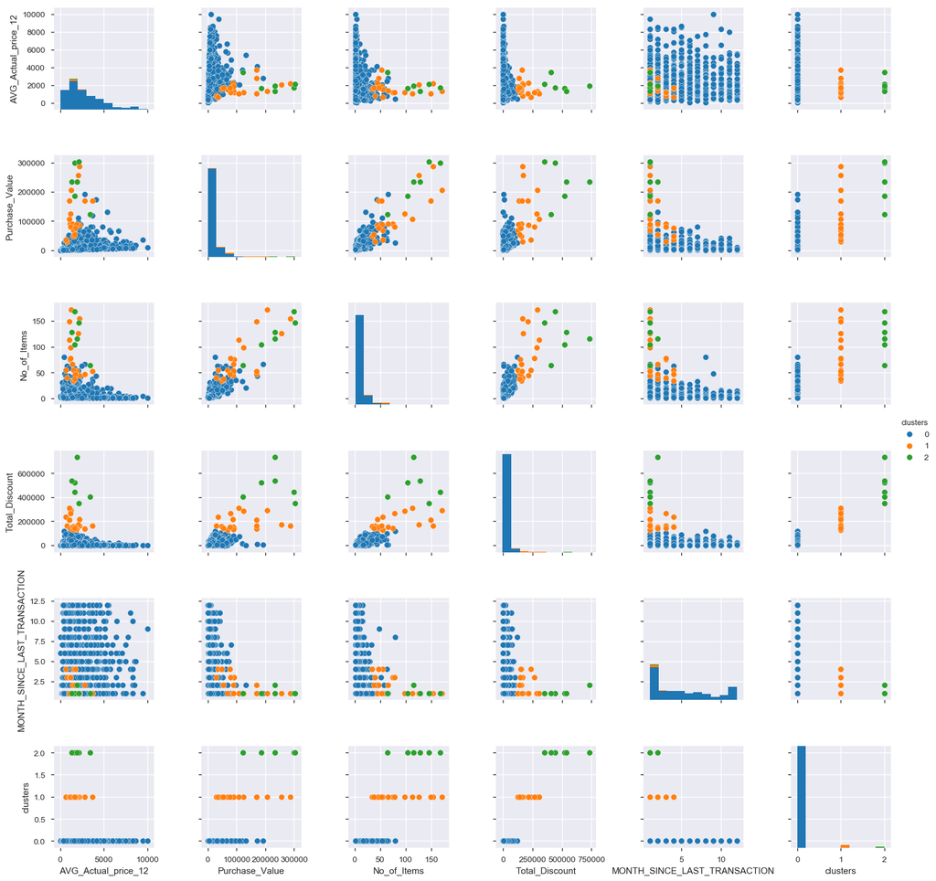

```python
### Visualizing the cluster based on each pair of columns

sns.pairplot(retail, hue='clusters')
```

### Post Segregation Analysis of each Cluster

(1) Cluster 0 - Denoted by BLUE dots (2) Cluster 1 - Denoted by Orange dots (3) Cluster 2 - Denoted by Green dots

### Attributes of each Cluster

(1) Cluster 0 - Denoted by BLUE dots

[output not shown]

[output not shown]

2. Also, MONTH_SINCE_LAST_TRANSACTION = 5 shows that these are not very frequent buyers and remained INACTIVE most of the time. These can be termed as **Quick Bargain Shoppers** , who are infrequent and price-sensitive shoppers

(2) Cluster 1 - Denoted by Orange dots

(3) Cluster 2 - Denoted by Green dots

1. Just 6 customers belong to this segment/cluster.
2. Can be termed as **Loyal Shoppers** having higher average spend, highest average item count and frequent buyers. These are the shoppers who are more inclined towards discounts and therefore had availed highest total discount value/points

**Recommendation**  
Cluster 2 is an ideal shopper segment for this retail supermarket however there are very few customers belong to this segment. Hence, various initiatives should be taken by Spencers’ Supermarket to move shoppers from Cluster 0 to Cluster 1 or 2. Few of the options are listed below...

- To offer more discount points on items with higher average price values
- To offer more incentives if buyers shop more frequently or make repeat purchases
- As lapsed accumulated discount points are highest in 2nd month of non-usage, it is further recommended not to lapse discount points after 2 months so that buyers will be lured to shop again to make use of those discount points before lapse
- Encashment of Discount points should be given on next purchase so that shoppers tend to come back again to use discount points

## For any further query, you may drop mail at tejinder.marwah@gmail.com